# Atividade AB2-2

Davi Celestino dos Santos Barbosa e João Victor Tenório Venancio

2025-11-17

## Contexto da base de dados

A base de dados escolhida é criada a partir de uma instituição de ensino superior (adquirido de diversas bases de dados distintas) relacionado a alunos matriculados em diferentes cursos de graduação, como agronomia, design, educação, enfermagem, jornalismo, administração, serviço social e tecnologias. O conjunto de dados original inclui informações conhecidas no momento da matrícula do aluno (trajetória acadêmica, dados demográficos e fatores socioeconômicos) e o desempenho acadêmico dos alunos ao final do primeiro e segundo semestres.

A base foi alterada para otimizar a eficiência da análise. Foram removidas no total 23 colunas de informações consideradas redundantes ou irrelevantes. Os nomes das colunas restantes, bem como os valores da variável ‘Resultado’, foram traduzidos para o português, colunas que utilizavam codificação numérica para representar categorias (como a coluna ‘Gênero’, que usava 0 e 1) foram convertidas para seus respectivos rótulos descritivos (‘Homem’ e ‘Mulher’), tornando a base mais legível.

Nesta atividade AB2-2, utilizaremos essa mesma base para aplicar conceitos de inferência estatística: intervalos de confiança, testes de hipóteses, comparação de proporções, ANOVA, correlação, regressão e transformação de dados.

### Importar a base de dados

```r
setwd("C:\\Projetos\\data-analysis-with-R\\data")

df <- read.csv("data_ADAPTED.csv", sep = ",", dec = ".", header = TRUE)

# Ajustando tipos das variáveis categóricas
df$Curso <- as.factor(df$Curso)
df$Deslocado <- as.factor(df$Deslocado)
df$Necessidades.educacionais.especiais <- as.factor(df$Necessidades.educacionais.especiais)
df$Devedor <- as.factor(df$Devedor)
df$Genero <- as.factor(df$Genero)
df$Bolsista <- as.factor(df$Bolsista)
df$Internacional <- as.factor(df$Internacional)
df$Resultado <- as.factor(df$Resultado)

str(df)
```

```
## 'data.frame':    4424 obs. of  14 variables:
##  $ Curso                                  : Factor w/ 17 levels "Advertising and Marketing Management",..: 3 16 6 9 15 11 12 16 14 14 ...
##  $ Ordem.de.prioridade.do.curso           : int  5 1 5 2 1 1 1 4 3 1 ...
##  $ Nota.da.qualificacao.anterior          : num  122 160 122 122 100 ...
##  $ Nota.de.admissao                       : num  127 142 125 120 142 ...
##  $ Deslocado                              : Factor w/ 2 levels "Nao","Sim": 2 2 2 2 1 1 2 2 1 2 ...
##  $ Necessidades.educacionais.especiais    : Factor w/ 2 levels "Nao","Sim": 1 1 1 1 1 1 1 1 1 1 ...
##  $ Devedor                                : Factor w/ 2 levels "Nao","Sim": 1 1 1 1 1 2 1 1 1 2 ...
##  $ Genero                                 : Factor w/ 2 levels "Homem","Mulher": 1 1 1 2 2 1 2 1 2 2 ...
##  $ Bolsista                               : Factor w/ 2 levels "Nao","Sim": 1 1 1 1 1 1 2 1 2 1 ...
##  $ Idade.na.inscricao                     : int  20 19 19 20 45 50 18 22 21 18 ...
##  $ Internacional                          : Factor w/ 2 levels "Nao","Sim": 1 1 1 1 1 1 1 1 2 1 ...
##  $ Materias.do.primeiro.semestre.aprovadas: int  0 6 0 6 5 5 7 0 6 5 ...
##  $ Media.das.notas.do.primeiro.semestre   : num  0 14 0 13.4 12.3 ...
##  $ Resultado                              : Factor w/ 3 levels "Desistente","Graduado",..: 1 2 1 2 2 2 2 1 2 1 ...
```

```r
summary(df)
```

```
##                                   Curso      Ordem.de.prioridade.do.curso
##  Nursing                             : 766   Min.   :0.000
##  Management                          : 380   1st Qu.:1.000
##  Social Service                      : 355   Median :1.000
##  Veterinary Nursing                  : 337   Mean   :1.728
##  Journalism and Communication        : 331   3rd Qu.:2.000
##  Advertising and Marketing Management: 268   Max.   :9.000
##  (Other)                             :1987
##  Nota.da.qualificacao.anterior Nota.de.admissao Deslocado
##  Min.   : 95.0                 Min.   : 95.0    Nao:1998
##  1st Qu.:125.0                 1st Qu.:117.9    Sim:2426
##  Median :133.1                 Median :126.1
##  Mean   :132.6                 Mean   :127.0
##  3rd Qu.:140.0                 3rd Qu.:134.8
##  Max.   :190.0                 Max.   :190.0
##
##  Necessidades.educacionais.especiais Devedor       Genero     Bolsista
##  Nao:4373                            Nao:3921   Homem :1556   Nao:3325
##  Sim:  51                            Sim: 503   Mulher:2868   Sim:1099
##
##
##
##
##
##  Idade.na.inscricao Internacional Materias.do.primeiro.semestre.aprovadas
##  Min.   :17.00      Nao:4314      Min.   : 0.000
##  1st Qu.:19.00      Sim: 110      1st Qu.: 3.000
##  Median :20.00                    Median : 5.000
##  Mean   :23.27                    Mean   : 4.707
##  3rd Qu.:25.00                    3rd Qu.: 6.000
##  Max.   :70.00                    Max.   :26.000
##
##  Media.das.notas.do.primeiro.semestre       Resultado
##  Min.   : 0.00                        Desistente :1421
##  1st Qu.:11.00                        Graduado   :2209
##  Median :12.29                        Matriculado: 794
##  Mean   :10.64
##  3rd Qu.:13.40
##  Max.   :18.88
##
```

## 1. Intervalo de confiança para a média

Neste item será construído um intervalo de confiança de 98% para a média da variável numérica **Média das notas do primeiro semestre** (`Media.das.notas.do.primeiro.semestre`).

```r
nota_media <- df$Media.das.notas.do.primeiro.semestre
nota_media <- na.omit(nota_media)

n1 <- length(nota_media)
media1 <- mean(nota_media)
dp1 <- sd(nota_media)
erro_padrao1 <- dp1 / sqrt(n1)

alpha1 <- 0.02                 # 98% de confiança
t_critico1 <- qt(1 - alpha1/2, df = n1 - 1)

IC1_inferior <- media1 - t_critico1 * erro_padrao1
IC1_superior <- media1 + t_critico1 * erro_padrao1

c(IC_inferior = IC1_inferior,
  media = media1,
  IC_superior = IC1_superior)
```

```
## IC_inferior       media IC_superior
##    10.47135    10.64082    10.81029
```

O vetor acima apresenta o intervalo de confiança de 98% para a média da variável **Média das notas do primeiro semestre**. Em linguagem interpretativa, dizemos que, com 98% de confiança, a média populacional dessa variável está contida entre o limite inferior e o limite superior encontrados.

## 2. Teste de hipótese para a média (uma amostra)

Agora, vamos testar se a média da mesma variável **Média das notas do primeiro semestre** é igual a um valor de referência hipotético. Vamos considerar como hipótese nula que a média populacional seja 12 pontos.

- Hipóteses:

$H_0: \mu = 12$  
$H_1: \mu \neq 12$

- Nível de significância: 5% ($\alpha = 0{,}05$).

```r
media_notas <- df$Media.das.notas.do.primeiro.semestre
media_notas <- na.omit(media_notas)

mu0 <- 12      # valor de referência
alpha2 <- 0.05

teste_media <- t.test(media_notas,
                      mu = mu0,
                      conf.level = 1 - alpha2)

teste_media
```

```
##
##  One Sample t-test
##
## data:  media_notas
## t = -18.664, df = 4423, p-value < 2.2e-16
## alternative hypothesis: true mean is not equal to 12
## 95 percent confidence interval:
##  10.49805 10.78359
## sample estimates:
## mean of x
##  10.64082
```

O teste t acima compara a média amostral com o valor de referência 12. Como o p-valor retornado é muito menor que 0,05, rejeitamos $H_0$ ao nível de 5% e concluímos que a média da **Média das notas do primeiro semestre** é significativamente diferente de 12 (na base utilizada, a média amostral é menor que 12).

## 3. Teste de hipótese para diferença de médias (duas amostras)

Neste item, comparamos as médias da variável **Média das notas do primeiro semestre** entre dois grupos: **bolsistas** e **não bolsistas**, representados pela variável categórica `Bolsista` (com categorias “Sim” e “Nao”).

- Variável numérica: `Media.das.notas.do.primeiro.semestre`
- Grupos: `Bolsista` = “Sim” e “Nao”
- Nível de significância: 4% ($\alpha = 0{,}04$).

Hipóteses:

$H_0: \mu_{bolsistas} = \mu_{nao\_bolsistas}$  
$H_1: \mu_{bolsistas} \neq \mu_{nao\_bolsistas}$

```r
dados_t3 <- subset(df, !is.na(Media.das.notas.do.primeiro.semestre) & !is.na(Bolsista))

# Médias, desvios-padrão e tamanhos de cada grupo
tapply(dados_t3$Media.das.notas.do.primeiro.semestre, dados_t3$Bolsista, mean)
```

```
##      Nao      Sim
## 10.17214 12.05879
```

```r
tapply(dados_t3$Media.das.notas.do.primeiro.semestre, dados_t3$Bolsista, sd)
```

```
##      Nao      Sim
## 5.135874 3.460745
```

```r
tapply(dados_t3$Media.das.notas.do.primeiro.semestre, dados_t3$Bolsista, length)
```

```
##  Nao  Sim
## 3325 1099
```

```r
# Teste de homogeneidade das variâncias (F de variâncias)
var.test(Media.das.notas.do.primeiro.semestre ~ Bolsista, data = dados_t3)
```

```
##
##  F test to compare two variances
##
## data:  Media.das.notas.do.primeiro.semestre by Bolsista
## F = 2.2024, num df = 3324, denom df = 1098, p-value < 2.2e-16
## alternative hypothesis: true ratio of variances is not equal to 1
## 95 percent confidence interval:
##  1.997355 2.422655
## sample estimates:
## ratio of variances
##           2.202366
```

```r
# Teste t para duas amostras independentes (Welch)
teste_t3 <- t.test(Media.das.notas.do.primeiro.semestre ~ Bolsista,
                   data = dados_t3,
                   var.equal = FALSE,
                   conf.level = 0.96)
teste_t3
```

```
##
##  Welch Two Sample t-test
##
## data:  Media.das.notas.do.primeiro.semestre by Bolsista
## t = -13.749, df = 2790, p-value < 2.2e-16
## alternative hypothesis: true difference in means between group Nao and group Sim is not equal to 0
## 96 percent confidence interval:
##  -2.168606 -1.604689
## sample estimates:
## mean in group Nao mean in group Sim
##          10.17214          12.05879
```

O teste t de duas amostras indica um p-valor extremamente pequeno (bem abaixo de 4%), de forma que rejeitamos $H_0$. Assim, concluímos que há evidência de diferença significativa entre as médias de desempenho de bolsistas e não bolsistas, sendo que os bolsistas apresentam, em média, notas mais altas no primeiro semestre.

## 4. Teste de hipótese para proporções (duas amostras)

Aqui, vamos comparar a **proporção de sucesso** entre dois grupos. Definimos como **sucesso** o aluno obter o resultado `"Graduado"` na variável `Resultado`. Os grupos comparados serão novamente **bolsistas** e **não bolsistas** (`Bolsista` = “Sim” e “Nao”).

- Sucesso: `Resultado == "Graduado"`
- Grupos: `Bolsista` = “Sim” e “Nao”
- Nível de significância: 5% ($\alpha = 0{,}05$).

Hipóteses:

$H_0: p_{bolsistas} = p_{nao\_bolsistas}$  
$H_1: p_{bolsistas} \neq p_{nao\_bolsistas}$

```r
# Contagem de sucessos (Graduado) em cada grupo
sucessos <- c(
  sum(df$Resultado == "Graduado" & df$Bolsista == "Nao"),
  sum(df$Resultado == "Graduado" & df$Bolsista == "Sim")
)

# Tamanho de cada grupo
totais <- c(
  sum(df$Bolsista == "Nao"),
  sum(df$Bolsista == "Sim")
)

sucessos
```

```
## [1] 1374  835
```

```r
totais
```

```
## [1] 3325 1099
```

```r
# Proporções amostrais
proporcoes <- sucessos / totais
proporcoes
```

```
## [1] 0.4132331 0.7597816
```

```r
# Teste de proporções (duas amostras)
teste_prop <- prop.test(sucessos, totais,
                        conf.level = 0.95,
                        correct = FALSE)
teste_prop
```

```
##
##  2-sample test for equality of proportions without continuity correction
##
## data:  sucessos out of totais
## X-squared = 396.79, df = 1, p-value < 2.2e-16
## alternative hypothesis: two.sided
## 95 percent confidence interval:
##  -0.3768486 -0.3162485
## sample estimates:
##    prop 1    prop 2
## 0.4132331 0.7597816
```

O teste de proporções indica um p-valor muito pequeno (menor que 0,05), levando à rejeição de $H_0$. Logo, concluímos que a proporção de alunos graduados é significativamente diferente entre bolsistas e não bolsistas, sendo maior entre os bolsistas.

## 5. ANOVA de um fator

Neste item, analisamos se a média da variável **Média das notas do primeiro semestre** difere entre os grupos definidos pela variável categórica `Resultado` (por exemplo, “Desistente”, “Graduado” e “Matriculado”).

- Variável numérica: `Media.das.notas.do.primeiro.semestre`
- Fator: `Resultado` (três categorias)
- Nível de significância: 5%.

Hipóteses:

$H_0: \mu_{Desistente} = \mu_{Graduado} = \mu_{Matriculado}$  
$H_1:$ pelo menos uma das médias difere das demais.

### Verificação dos pressupostos

```r
dados_q5 <- subset(df, !is.na(Media.das.notas.do.primeiro.semestre) & !is.na(Resultado))

# Teste de normalidade (Shapiro-Wilk) em uma amostra de até 500 observações de cada grupo
set.seed(123)

by(dados_q5$Media.das.notas.do.primeiro.semestre, dados_q5$Resultado, function(x) {
  x_amostra <- if (length(x) > 500) sample(x, 500) else x
  shapiro.test(x_amostra)
})
```

```
## dados_q5$Resultado: Desistente
##
##  Shapiro-Wilk normality test
##
## data:  x_amostra
## W = 0.73478, p-value < 2.2e-16
##
## ------------------------------------------------------------
## dados_q5$Resultado: Graduado
##
##  Shapiro-Wilk normality test
##
## data:  x_amostra
## W = 0.61954, p-value < 2.2e-16
##
## ------------------------------------------------------------
## dados_q5$Resultado: Matriculado
##
##  Shapiro-Wilk normality test
##
## data:  x_amostra
## W = 0.61155, p-value < 2.2e-16
```

```r
# Teste de homogeneidade de variâncias (Bartlett)
bartlett.test(Media.das.notas.do.primeiro.semestre ~ Resultado, data = dados_q5)
```

```
##
##  Bartlett test of homogeneity of variances
##
## data:  Media.das.notas.do.primeiro.semestre by Resultado
## Bartlett's K-squared = 1162.4, df = 2, p-value < 2.2e-16
```

Em amostras grandes, o teste de normalidade tende a ser muito sensível, rejeitando a normalidade mesmo para desvios pequenos. Ainda assim, a ANOVA é relativamente robusta a pequenas violações quando os tamanhos amostrais são grandes e semelhantes.

### Ajuste da ANOVA

```r
anova_q5 <- aov(Media.das.notas.do.primeiro.semestre ~ Resultado,
                data = dados_q5)
summary(anova_q5)
```

```
##               Df Sum Sq Mean Sq F value Pr(>F)
## Resultado      2  25321   12661   713.5 <2e-16 ***
## Residuals   4421  78447      18
## ---
## Signif. codes:  0 '***' 0.001 '**' 0.01 '*' 0.05 '.' 0.1 ' ' 1
```

```r
# Médias por grupo
tapply(dados_q5$Media.das.notas.do.primeiro.semestre, dados_q5$Resultado, mean)
```

```
##  Desistente    Graduado Matriculado
##    7.256656   12.643655   11.125257
```

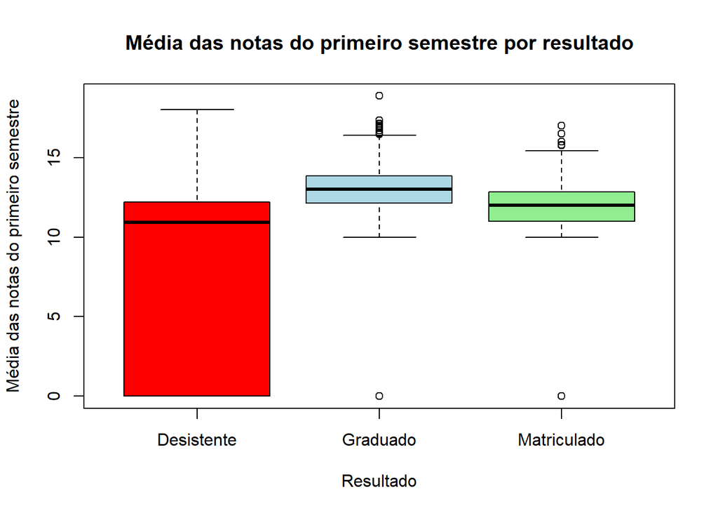

```r
# Boxplot para visualizar as distribuições por grupo
boxplot(Media.das.notas.do.primeiro.semestre ~ Resultado,
        data = dados_q5,
        main = "Média das notas do primeiro semestre por resultado",
        xlab = "Resultado",
        ylab = "Média das notas do primeiro semestre",
        col = c("red", "lightblue", "lightgreen"))
```

O resultado da ANOVA apresenta um p-valor extremamente pequeno (bem menor que 0,05), o que leva à rejeição de $H_0$. Portanto, concluímos que há diferenças significativas entre as médias de desempenho dos grupos de `Resultado`. As médias mostram, em geral, que alunos **Graduados** têm média mais alta, seguidos pelos **Matriculados**, enquanto os **Desistentes** apresentam as menores médias.

## 6. Correlação entre duas variáveis numéricas

Vamos estudar a correlação entre as variáveis numéricas:

- `Nota.de.admissao` (nota utilizada para admissão)
- `Media.das.notas.do.primeiro.semestre` (desempenho no 1º semestre).

Hipóteses do teste de correlação:

$H_0: \rho = 0$ (não há correlação linear)  
$H_1: \rho \neq 0$ (há correlação linear diferente de zero).

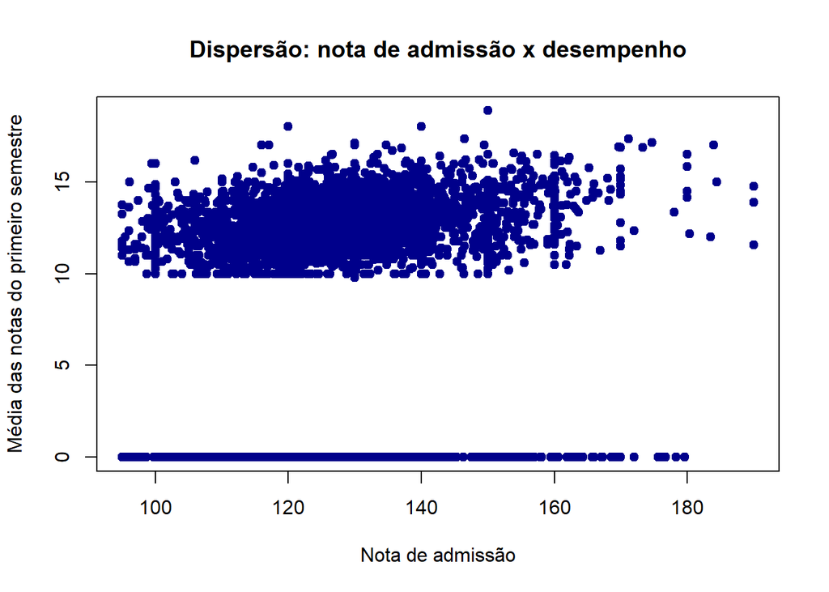

```r
dados_q6 <- subset(df, !is.na(Nota.de.admissao) & !is.na(Media.das.notas.do.primeiro.semestre))

# Gráfico de dispersão
plot(dados_q6$Nota.de.admissao,
     dados_q6$Media.das.notas.do.primeiro.semestre,
     pch = 19, col = "darkblue",
     xlab = "Nota de admissão",
     ylab = "Média das notas do primeiro semestre",
     main = "Dispersão: nota de admissão x desempenho")
```

```r
# Coeficiente de correlação de Pearson
r_pearson <- cor(dados_q6$Nota.de.admissao,
                 dados_q6$Media.das.notas.do.primeiro.semestre)
r_pearson
```

```
## [1] 0.07386842
```

```r
# Teste de hipótese para correlação
teste_cor <- cor.test(dados_q6$Nota.de.admissao,
                      dados_q6$Media.das.notas.do.primeiro.semestre)
teste_cor
```

```
##
##  Pearson's product-moment correlation
##
## data:  dados_q6$Nota.de.admissao and dados_q6$Media.das.notas.do.primeiro.semestre
## t = 4.9256, df = 4422, p-value = 8.719e-07
## alternative hypothesis: true correlation is not equal to 0
## 95 percent confidence interval:
##  0.04449651 0.10311274
## sample estimates:
##        cor
## 0.07386842
```

O coeficiente de correlação de Pearson é positivo, mas de pequena magnitude (próximo de 0,07), indicando uma associação linear **fraca** entre a nota de admissão e o desempenho no primeiro semestre. Devido ao grande tamanho amostral, o p-valor do teste é muito pequeno, o que leva à rejeição de $H_0$, mas o valor de $r$ mostra que, na prática, a relação linear é fraca.

## 7. Regressão linear simples

Usando as mesmas duas variáveis numéricas do item anterior, ajustaremos um modelo de regressão linear simples, considerando:

- Variável resposta (Y): `Media.das.notas.do.primeiro.semestre`
- Variável preditora (X): `Nota.de.admissao`.

Modelo: $Y = \beta_0 + \beta_1 X + \varepsilon$.

```r
modelo_q7 <- lm(Media.das.notas.do.primeiro.semestre ~ Nota.de.admissao,
                data = df)

summary(modelo_q7)
```

```
##
## Call:
## lm(formula = Media.das.notas.do.primeiro.semestre ~ Nota.de.admissao,
##     data = df)
##
## Residuals:
##      Min       1Q   Median       3Q      Max
## -11.9409   0.4221   1.7037   2.7391   7.6654
##
## Coefficients:
##                  Estimate Std. Error t value Pr(>|t|)
## (Intercept)      7.503687   0.641036  11.706  < 2e-16 ***
## Nota.de.admissao 0.024706   0.005016   4.926 8.72e-07 ***
## ---
## Signif. codes:  0 '***' 0.001 '**' 0.01 '*' 0.05 '.' 0.1 ' ' 1
##
## Residual standard error: 4.831 on 4422 degrees of freedom
## Multiple R-squared:  0.005457,   Adjusted R-squared:  0.005232
## F-statistic: 24.26 on 1 and 4422 DF,  p-value: 8.719e-07
```

```r
# Resíduos do modelo
residuos_q7 <- residuals(modelo_q7)

# Teste de normalidade dos resíduos (em uma amostra)
set.seed(123)
residuos_amostra <- if (length(residuos_q7) > 500) sample(residuos_q7, 500) else residuos_q7
shapiro.test(residuos_amostra)
```

```
##
##  Shapiro-Wilk normality test
##
## data:  residuos_amostra
## W = 0.68093, p-value < 2.2e-16
```

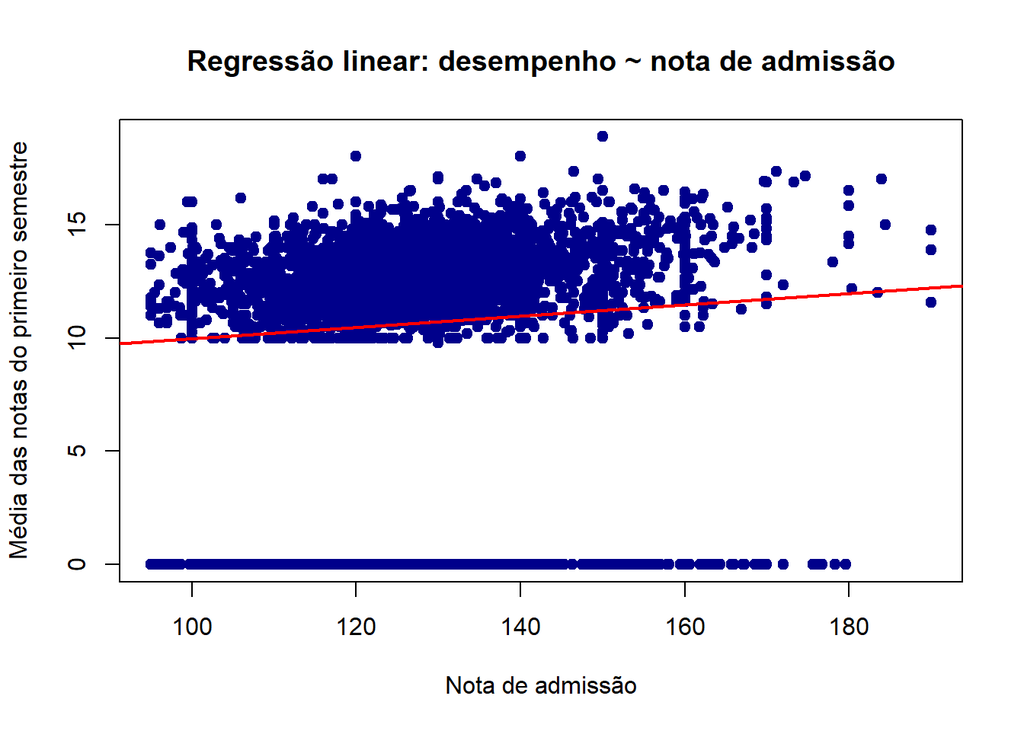

```r
# Gráfico de dispersão com a reta ajustada
plot(df$Nota.de.admissao,
     df$Media.das.notas.do.primeiro.semestre,
     pch = 19, col = "darkblue",
     xlab = "Nota de admissão",
     ylab = "Média das notas do primeiro semestre",
     main = "Regressão linear: desempenho ~ nota de admissão")
abline(modelo_q7, col = "red", lwd = 2)
```

## 8. Transformação de dados

Por fim, vamos escolher uma variável numérica que não apresenta distribuição aproximadamente normal e aplicar uma transformação. Usaremos novamente a variável `Media.das.notas.do.primeiro.semestre`, que possui muitos valores concentrados em determinadas faixas (incluindo zeros), gerando assimetria.

### Verificando a normalidade antes da transformação

```r
set.seed(123)

variavel_q8 <- na.omit(df$Media.das.notas.do.primeiro.semestre)

# Teste de normalidade em uma amostra
amostra_q8 <- if (length(variavel_q8) > 500) sample(variavel_q8, 500) else variavel_q8
shapiro.test(amostra_q8)
```

```
##
##  Shapiro-Wilk normality test
##
## data:  amostra_q8
## W = 0.67953, p-value < 2.2e-16
```

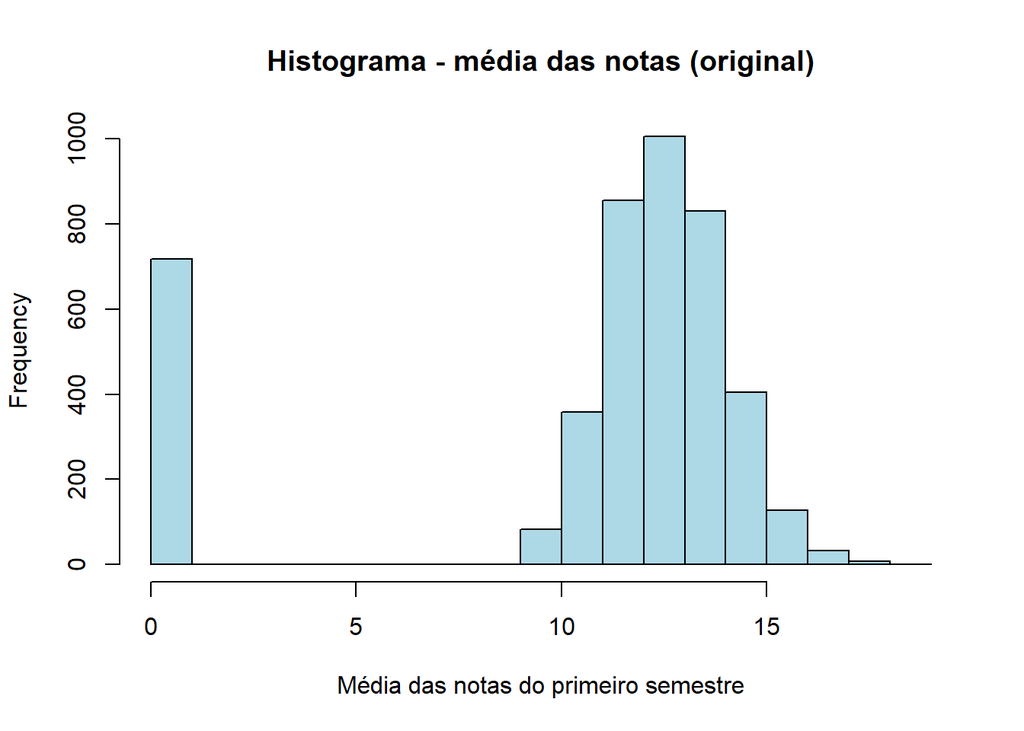

```r
# Histograma na escala original
hist(variavel_q8,
     main = "Histograma - média das notas (original)",
     xlab = "Média das notas do primeiro semestre",
     col = "lightblue")
```

Os resultados do teste de Shapiro-Wilk e o histograma indicam que a distribuição da variável original não é bem ajustada por uma normal, apresentando assimetria.

### Aplicando a transformação logarítmica

Como os valores são não negativos, aplicaremos uma transformação logarítmica do tipo $\log(x + 1)$ para evitar problemas com o logaritmo de zero.

```r
variavel_log <- log(variavel_q8 + 1)

# Teste de normalidade após a transformação (em amostra)
amostra_log <- if (length(variavel_log) > 500) sample(variavel_log, 500) else variavel_log
shapiro.test(amostra_log)
```

```
##
##  Shapiro-Wilk normality test
##
## data:  amostra_log
## W = 0.52864, p-value < 2.2e-16
```

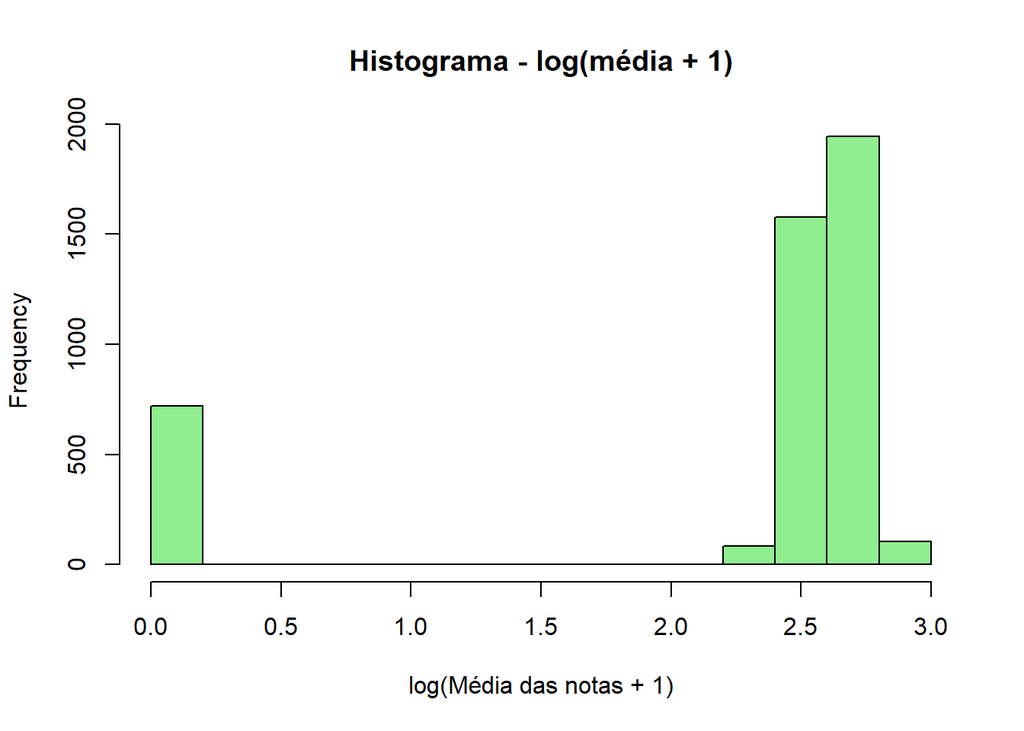

```r
# Histograma após a transformação
hist(variavel_log,
     main = "Histograma - log(média + 1)",
     xlab = "log(Média das notas + 1)",
     col = "lightgreen")
```

### Revertendo a transformação para interpretar na escala original

```r
media_original <- mean(variavel_q8)
media_log <- mean(variavel_log)
media_revertida <- exp(media_log) - 1

c(media_original = media_original,
  media_transformada = media_log,
  media_revertida = media_revertida)
```

```
##     media_original media_transformada    media_revertida
##          10.640822           2.188739           7.923951
```